# TU BASICS: Regression modeling

September 18<sup>th</sup>, 2019

## Class objectives

Be able to:

- identify wether a linear or logistic regression would let you answer the scientific question of interest given the available data
- propose an adequate model for the question (model, outcome, predictors)
- fit the model in `R`
- interpret and discuss the results

## Introduction

## Linear model

**linear regression** is also called **linear model**:

- simple linear model: \(Y\) and \(X\)
- multiple linear model: \(Y\) and \(X_1\), \(X_2\), …, \(X_p\)
- generalized linear models (and in particular logistic regression): \(Y\) and \(X_1\), \(X_2\), …, \(X_p\) when \(Y\) is not Gaussian

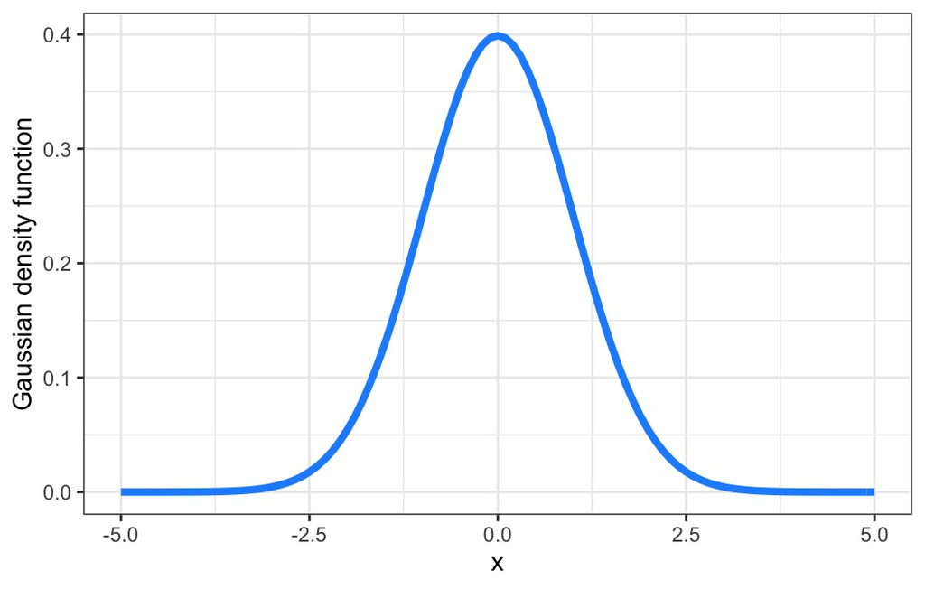

## Motivation example: Birth weight study

Study on risks factor for low birth weights from Baystate medical center in Springfield (MA, USA) during 1986 [Hosmer & Lemeshow (1989), *Applied Logistic Regression*]

- `low`: low birth weight indicator coded as: `1` (low birth weight, i.e. \(\leq 2.5kg\)) and `0` (normal birth weight)  
- `age`: mother’s age (in years) at the time of birth  
- `lwt`: mother’s weight (in pounds) at the time of the last menstrual period  
- `race`: mother’s race coded as: `1` (white), `2` (black) and `3` (other)  
- `smoke`: mother’s smoking status coded as `1` (smoker) and `0` (non-smoker)  
- `ptl`: number of previous premature labours  
- `ht`: hypertension history indicator coded as: `1`(yes) and `0` (no)  
- `ui`: uterine irritability indicator coded as: `1` (yes) and `0` (no)  
- `ftv`: number of physician visits during the first trimester  
- `bwt`: infant’s birth weight (in grams)

## Correlation

Quantifies the relationship between 2 continuous variables \(X\) and \(Y\)

## Correlation

Are \(X\) and \(Y\) values linked ?

A few definitions:

- \(cor(X, Y) = \dfrac{Cov(X, Y)}{\sqrt{Var(X)Var(Y)}}\)
- \(Var(X) = E[(X-E(X))^2]\)
- \(Cov(X,Y)=E[(X-E(X))(Y-E(Y))]=E(XY)-E(X)E(Y)\)
- \(E(X) = \sum_{x}x\mathbb{P}(X=x)\)

## Estimations for correlation

Those quantities are estimated over a sample \((x_1, \dots, x_n)\) by:

- \(\bar{x} = \frac{1}{n}\sum_{i=1}^n x_i\)
- \(s^2_x = \dfrac{\sum_{i=1}^n (x_i-\bar{x})^2}{n-1}\)
- \(s_{xy} = \dfrac{\sum_{i=1}^n(x_i-\bar{x})(y_i-\bar{y})}{n-1}\)
- \(r=\frac{s_{xy}}{\sqrt{s^2_{x}s^2_{y}}}\)

**NB:** the correlation is a scaled version of the covariance,  
it is thus an association measure between \(-1\) and \(1\)  
(the closer to 0, the weaker the link)

## Correlation between the mother’s age and the birth weight

Here, the correlation between the mother’s age and the birth weight is \(0.09\)

## Other correlations and associations measure

This is the linear correlation, also called Pearson correlation coefficient.

Many other measures have been proposed to explore and quantify the link between two variables:

- Spearman correlation
- Mutual Information
- Maximum Information Criterion
- …

## Simple linear Regression

Also quantifies the relationship between 2 continuous variables \(X\) and \(Y\)

## Average birth weight by mother’s age

| age | n | bwt_mean | bwt_se |
| --- | --- | --- | --- |
| 14 | 3 | 2967.333 | 843.3447 |
| 15 | 3 | 2504.000 | 237.7036 |
| 16 | 7 | 3331.714 | 695.1493 |
| 17 | 12 | 2758.500 | 443.3844 |
| 18 | 10 | 2998.200 | 573.6156 |
| 19 | 16 | 3051.875 | 681.9460 |
| 20 | 18 | 2860.167 | 694.1185 |
| 21 | 12 | 2724.167 | 698.4330 |
| 22 | 13 | 3150.231 | 551.7235 |
| 23 | 13 | 2951.692 | 640.3095 |

[output cut: 14 more lines]

## Linear Model

It all started with a scatter plot…

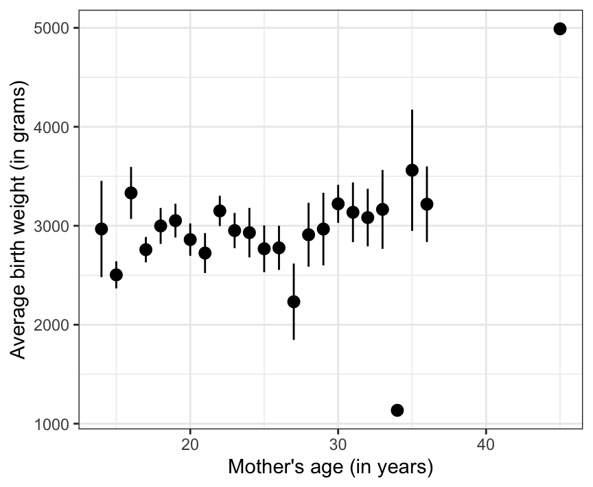

\(\Rightarrow\) Regression, a.k.a. **linear** model:  
what is the optimal line going through this scatter plot ?

## “Best” line ?

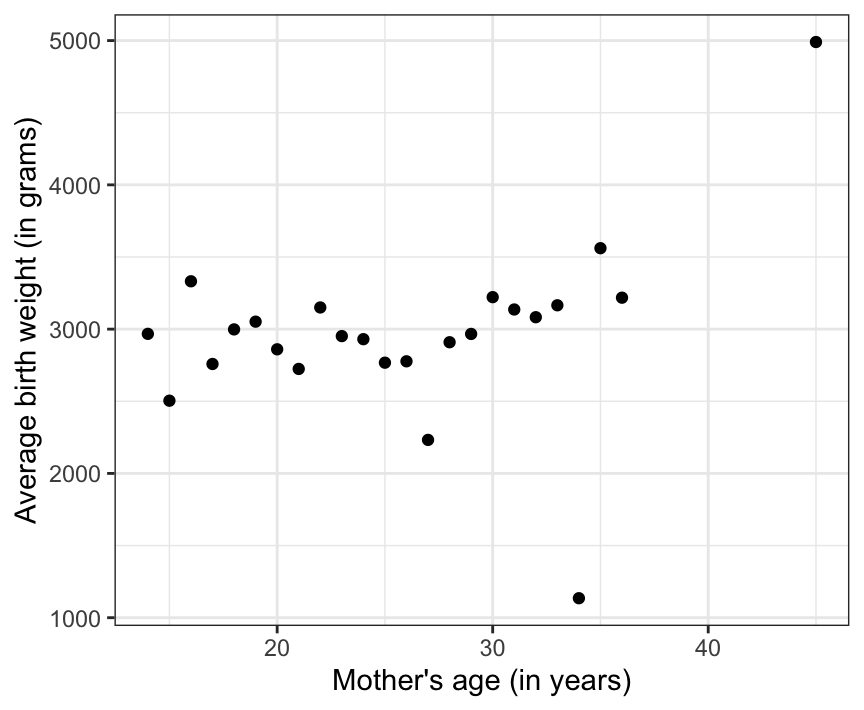

## “Best” line ?

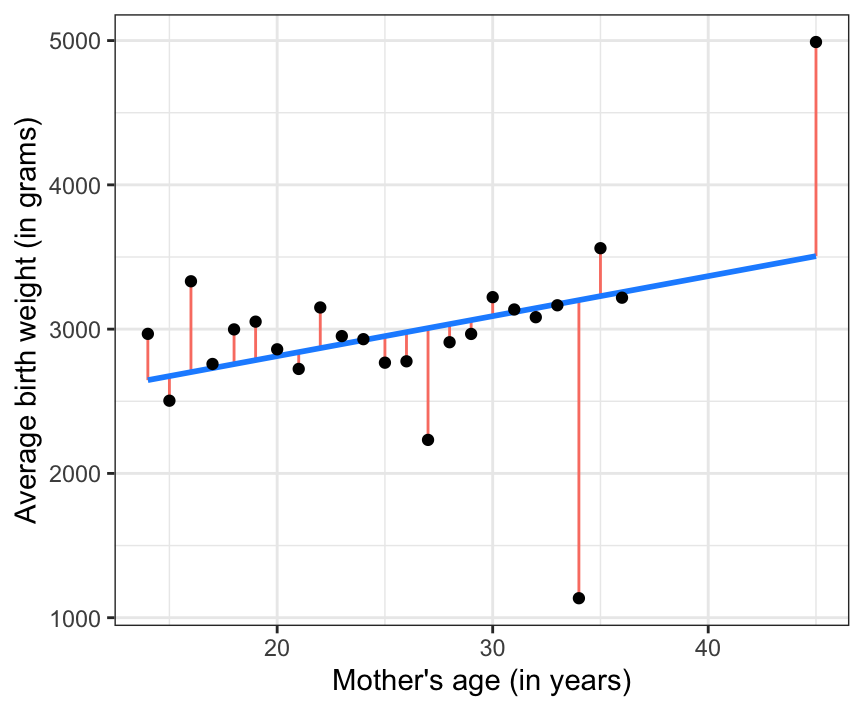

## A Line equation

\[y = a + bx\]

We can write such an equation for relating \(y_i\) values to \(x_i\) values:

\[y_i = \beta_0 + \color{blue}{\beta_1} x_i + \color{red}{\varepsilon_i}\]

- \(\beta_0\) is interpreted as the average value of \(Y\) when \(x_i\) is 0
- \(\beta_1\) represents the slope of the regression line
- \(\varepsilon_i\) is the random error separating the regression line from the observed value

## Conditional distribution

The regression problem can be formalized as:

*How do we characterize the conditional distribution of the random variable \(Y\) knowing the values \(x\) of the random variable \(X\) ?*

\[Y|x \;\sim\; ?\] using:

- its expected value \(E(Y|x)\)
- its variance \(Var(Y|x)\)
- its probability distribution

## Regression equation

The simple linear model can be written as:

\[Y|x\;\sim\;\mathcal{N}(\beta_0 + \color{blue}{\beta_1}x,\; \color{red}{\sigma^2})\]

The **regression equation** then writes itself as: \[E(Y|x) = \beta_0 +\beta_1 x\]

## Hypothesis of this linear model

1. **linearity** of the relationship between \(Y\) and \(X\)
2. **homoskedasticity** of the observations \(y_i\) (same variance across observations)
3. **normality** of the observations \(y_i\)
4. **independence** of the \(y_i\) across observations

## Linearity hypothesis

When X increases by 1 unit, Y increases **on average** by \(\beta_1\) units  
**regardless of the inital value of X**

\(\begin{align*} E(Y_i|X_i=a+1) - E(Y_i|X_i=a) &= [\beta_0 +\beta_1(a+1)]\\&\quad-[\beta_0 +\beta_1a]\\ &=\beta_1 \end{align*}\)

## Homoskedasticity hypothesis

\(Var(Y_i|x_i) = \sigma^2\) for all \(x_i\)  
*usually not enough data to assess numerically – instead a graphical assesment can be performed*

*Ex*: for any mother’s age (\(x\)), the conditional birth weight (\(Y|x\)) must have the same variance

[figure not shown]

## Normality hypothesis

\(Y_i|x_i \sim \mathcal{N}\) for all \(x_i\)  
*usually not enough data to assess – instead a graphical assessment can be performed on the marginal histogram of \(Y\) (instead of \(Y|x\))*

*Ex*: for any mother’s age (\(x\)), the conditional birth weight (\(Y|x\)) must have a Gaussian distribution

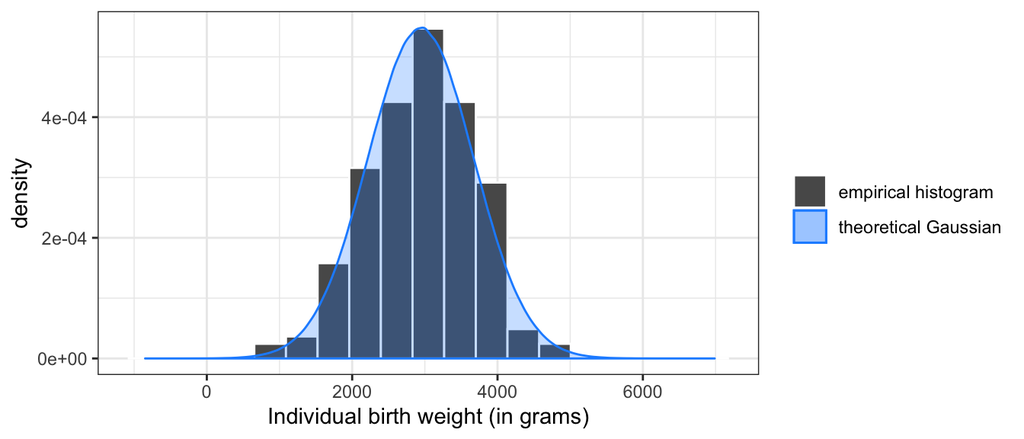

## Independence hypothesis

\(Cov(Y_i, Y_j) = 0\) for all \(i \neq j\)  
*Such a hypothesis cannot be checked directly on the data, but must be assessed from what we know from the data collection process*

*Ex*: birth weights of the 189 infants are independent, assuming there is no twins (or even siblings) among them

## Random errors & residuals

- \(E(Y_i|x_i) = \beta_0 + \beta_1 x_i \quad (i = 1, \dots, n)\)
- \(Y_i = \beta_0 + \beta_1 x_i + \varepsilon_i \quad (i = 1, \dots, n)\)

where \(\beta_0 + \beta_1 x_i\) is the determinist part  
and \(\varepsilon_i\) is the random part: \[\varepsilon_i=Y_i-E(Y_i|x_i)=Y_i-(\beta_0 + \beta_1 x_i) \enspace\]

\(\varepsilon_i\) are called the **random errors**, or the **residuals**

## Random errors hypothesis

The 4 hypothesis from the linear model can be expressed with respect to the random errors:

- **independence** of the \(\varepsilon_i\) \(\Rightarrow\) independence of \(Y_i\)
- \(E(\varepsilon_i)=0\) \(\Rightarrow\) **linearity** hypothesis
- \(Var(\varepsilon_i)=\sigma^2\) \(\Rightarrow\) \(Var(Y_i|x_i)=\sigma^2\) (**homoskedasticity**)
- **normality** of the \(\varepsilon_i\) \(\Rightarrow\) normality of the \(Y_i|x_i\).

## Summary on the hypothesis

- **Linearity**: \(E(Y_i|X_i=x_i) = E(Y_i|x_i) = \beta_0 + \beta_1 x_i\) or \(E(\varepsilon_i)=0\) \((i = 1, \dots, n)\)  
  ✅ *check*: \(X \times Y\) scatter plot + post-fit residuals
- **Homoskedasticity**: \(Var(Y_i|x_i) = \sigma^2\) or \(Var(\varepsilon_i)=\sigma^2\) for all \(i\)  
  ✅ *check*: \(X \times Y\) scatter plot + post-fit residuals
- **Normality**: \(Y_i|x_i \sim \mathcal{N}\) for any \(x_i\) or \(\varepsilon_i \sim \mathcal{N}\) for all \(i\)  
  ✅ *check*: histogram of \(Y\) before estimation + post-fit residuals
- **Independence**: \(cov(Y_i, Y_j) = 0\) or \(cov(\varepsilon_i, \varepsilon_j) = 0\) for all pairs \(i \neq j\)  
  ✅ *check*: context

## linear model and Ordinary Least Squares (OLS)

One way to define the “Best” line is the line that will minimize the **sum of squarred errors**.

The *Least Squares* criteria minimizes: \[\Phi(\beta_0,\beta_1)=\sum_{i=1}^n(y_i-\beta_0-\beta_1x_i)^2\]

## OLS estimates

Minimizing \(\Phi(\beta_0,\beta_1)\) gives \(\hat{\beta}_0\) and \(\hat{\beta}_1\) (solved setting the partial derivatives with respect to \(\beta_1\) and \(\beta_0\) respectively to 0):

\[\hat{\beta}_1 = \frac{\sum_{i=1}^n (x_i - \bar{x})(y_i - \bar{y})} {\sum_{i=1}^n (x_i - \bar{x})^2} \quad \mbox{et} \quad \hat{\beta}_0 = \bar{y} - \hat{\beta_1}\bar{x}\]

with \(\bar{y} = \frac{1}{n} \sum_{i=1}^n y_i\) and \(\bar{x} = \frac{1}{n} \sum_{i=1}^n x_i\)

Another possible formula is: \(\hat{\beta}_1 = \frac{\overline{xy} - \bar{x} \bar{y}} {\overline{x^2} - \bar{x}^2}\)  
with \(\overline{xy} = \frac{1}{n} \sum_{i=1}^n x_i y_i\) and \(\overline{x^2} = \frac{1}{n} \sum_{i=1}^n x^2_i\)

## OLS estimators properties

It can be shown that, as \(n\) (the number of observations) gets larger:

- \(\hat{\beta_0} \sim \mathcal{N}\left(\beta_0, \sigma^2_{\hat{\beta_0}}\right)\) \(\Rightarrow\) \(\dfrac{\hat{\beta_0}-\beta_0}{s(\hat{\beta_0})}\sim Student(n-2)\)
- \(\hat{\beta_1} \sim \mathcal{N}\left(\beta_1, \sigma^2_{\hat{\beta_1}}\right)\) \(\Rightarrow\) \(\dfrac{\hat{\beta_1}-\beta_1}{s(\hat{\beta_1})}\sim Student(n-2)\)

## Confidence Intervals (CI)

It follows that

- Confidence interval at \(100\times(1-\alpha)\%\) for \(\beta_0\) : \[[\hat{\beta_0}\pm t^{n-2}_{1-\alpha/2}\times s(\hat{\beta}_0)]\]
- Confidence interval at \(100\times(1-\alpha)\%\) for \(\beta_1\) : \[[\hat{\beta_1}\pm t^{n-2}_{1-\alpha/2}\times s(\hat{\beta}_1)]\]

## Student’s Test

The most important test in the simple linear model is whether \(\hat{\beta}_1\) is significantly different from \(0\),  
i.e. does \(X\) significantly informs the prediction of \(Y\):

- null hypothesis \(H_0:\ \beta_1=0\)  
  (*no association between \(Y\) & \(X\)*)
- alternative hypothesis \(H_1:\ \beta_1\neq0\)  
  (*linear association between \(Y\) & \(X\)*)

\(\Rightarrow\) *test statistics:* \(T=\frac{\hat{\beta}_1}{s(\hat{\beta}_1)}\underset{H_0}{\sim} Student(n-2)\)

## Link between Tests and CI

- \(CI_{1-\alpha\%}(\beta_1)\) contains 0 \(\Leftrightarrow\) non-rejection of \(H_0\) at the significance level \(\alpha\)
- \(CI_{1-\alpha\%}(\beta_1)\) does **NOT** contain 0 \(\Leftrightarrow\) rejection of \(H_0\) at the significance level \(\alpha\)

CI gives a idea of the precision around the estimation of \(\beta_1\), but not its significance level (p-value)…  
One can only know if the p-value is below or above \(\alpha\) from the CI

## Link between correlation and simple linear regression

\(R^2\) coefficient is the square of the correlation and is related to \(\beta_1\)

\[R^2 = \beta_1^2\frac{\sigma_X^2}{\sigma_Y^2}\]

The correlation estimator can then be written as: \[r = \hat{\beta_1}\frac{s_X}{s_Y}\]

## Likelihood approach

📝

- 👉 write the likelihood for the simple linear model

## Practicals 1

+

## Practicals 2

- 👉 using the `lm()` function (look at the **help** and the **examples**), fit a simple linear model explaining the *average birth weight* from the *mother’s age*
- 👉 explore the results with the `ls()` function, the `$` operator and the `summary()` function
- 👉 assess the linear model assumpions
- 👉 interpret your results (take particular care for \(\beta_0\))
- 👉 fit a second simple linear model explaining the *individual birth weight* from the *mother’s age* using the non-aggregated original data
- 👉 compare the results. How can you explain the differences ?

## Multiple Linear Regression

Quantifies the linear relationship between a Gaussian variable \(Y\) and multiple variables \(X_1\), \(X_2\), …, \(X_p\)

## Regression analysis steps

Regardless of which regression model you are using:

1. **Model specification** according to the research question, and the data available
2. **Estimation** with point estimates and **Confidence Intervals** for the model parameters
3. Significance testing for each model parameters of interest
4. Model adequation diagnoses
5. Results presentation (often as a table)
6. Results interpretation and discussion

## Multiple linear Regression

\[\begin{align*} y_i &= \beta_0 + \color{blue}{\beta_1} x_{1i} + \color{blue}{\beta_2} x_{2i} + \dots + \color{blue}{\beta_p} x_{2p} + \color{red}{\varepsilon_i}\\ &= \beta_0 + \left(\sum_{i=1}^p\color{blue}{\beta_i} x_i\right) + \color{red}{\varepsilon_i} \end{align*}\]

## Matrix notation

\[Y= X\boldsymbol{\beta} + \epsilon\] \[ Y = \begin{bmatrix} Y_{1} \\ \vdots \\ Y_{n} \end{bmatrix} ,\quad X = \begin{bmatrix} 1 & x_{11} & x_{21} & \dots & x_{p1} \\ \vdots & \vdots & \vdots & \vdots & \vdots\\ 1 & x_{1n} & x_{2n} & \dots & x_{pn} \end{bmatrix} ,\quad \boldsymbol{\beta} = \begin{bmatrix} \beta_{0} \\ \beta_{1} \\ \beta_2 \\ \vdots \\ \beta_p \end{bmatrix} ,\quad\] \[\varepsilon = \begin{bmatrix} \varepsilon_{1} \\ \vdots \\ \varepsilon_{n} \end{bmatrix} . \]

## Ordinary Least Squares formula

\[\boldsymbol{\widehat{\beta}}= (X^TX)^{-1}X^TY\]

❗️Requires \(X^TX\) to be invertible !

This is no the case if:

- \(p \geq n\) (high-dimensional case)
- \(X^TX\) is not of full rank (e.g. one covariate can be computed as a perfect linear combination of the other)  
  *numerical instabilities when covaraites are **extremely correlated***

## Indicator coding

For categorical predictors, the design matrix \(X\) uses modality indicator variables:

\(X_j = \begin{bmatrix} m_1 \\ m_K \\ m_1 \\ \vdots \\ m_{K} \end{bmatrix}\) \(\rightarrow\,\) \(X_{m_1}^j = \begin{bmatrix} 1 \\ 0 \\ 1 \\ \vdots \\ 0 \end{bmatrix} ,\,\) \(\dots,\,\) \(X_{m_n}^j = \begin{bmatrix} 0 \\ 1 \\ 0 \\ \vdots \\ 1 \end{bmatrix}\)

❗️*Need to set a **reference** class to ensure identifiability*

```r
?model.matrix()
```

## Interactions

\[X_j\times X_m\]

\(\Rightarrow\) the value of \(X_m\) modifies the effect of \(X_j\) on \(Y\)

❗️*if an interaction is included in a linear model, the main effects involved must always be included as well*  
**otherwise the interaction is not interpretable**

*Due to numerical complexity, it is very rare to use higher order (\(>2\)) interactions…*

## Confounding

potential confounders must be included in the model !  
\(X_2\) is a counfounding factor for the relationship between \(X_1\) and \(Y\) if:

- \(X_2\) is associated with both \(X_1\) and \(Y\)
- \(X_2\) is a direct or indirect cause of \(Y\), but not a consequence
- \(X_2\) is not on the causal path between \(X_1\) and \(Y\)

Assessthe relative variation \(RV=\dfrac{\left|\beta_1^{model1} - \beta_1^{model2}\right|}{\beta_1^{model1}}\)  
\(\Rightarrow\) *arbitrary thresholds of 10% or 20% to declare potential confounding factors*

## Likelihood Ratio Test

The Likelihood Ratio Test (LRT) can be used to compare **nested models**, in particular for testing several coefficients at once.

AIC & BIC criteria:

- based on \(-2\,\text{log-likelihood}\)
- penalize for the number of parameters (**the more parameters, the better the fit, *mechanically***)
- can be used to compare **non-nested models *on the same data***
- the lower the better

\(AIC=2p-2\,\text{log-likelihood}\)  
\(BIC=p\log(n)-2\,\text{log-likelihood}\)  
\(R_{adj}^{2}=1-(1-R^{2}){n-1 \over n-p-1}\)

## Multiple testing

❗️when \(p\) becomes large, the number of coefficients tested in the model becomes large as well, and one must be careful and deal with the **multiple testing issue**

*To be continued…*

## Model selection

One of the recurring question in multiple regression is:

> Which variables should be included in the model ?

Often dealt with *stepwise* method inclusion

❗️this is not statistically sound and should be avoided

Modern methods, such as the **LASSO** or **Random Forest** encompass a framework for suitable variable selection in multivariate regression models… *To be continued*

## Practicals 3

+

- 👉 load the data from `birthweight_data.txt`
- 👉 how can you best explain the *individual birth weight* from the other variables ?

## Class objectives

Be able to:

- identify wether a linear or logistic regression would let you answer the scientific question of interest given the available data
- propose an adequate model for the question (model, outcome, predictors)
- fit the model in `R`
- interpret and discuss the results

## Generalized linear models (GLM)

Quantifies the linear relationship between a **non-gaussian** variable \(Y\) and multiple variables \(X_1\), \(X_2\), …, \(X_p\)

## Binary outcome & regression

Linear regression model:

\[E(Y|x_1,x_2,\dots,x_p) = \beta_0+\beta_1x_1 + \beta_2 x_2 +\dots + \beta_p x_p\]

If \(Y\) is a binary variable: \(\in\ [0, 1]\):

\[E(Y|x_1,x_2,\dots,x_p) = \mathbb{P}(Y=1|x_1,x_2,\dots,x_p)\] ❗️\(E(Y|x_1,x_2,\dots,x_p)\ \in\ [0, 1]\) (probability) while \(\beta_0+\beta_1x_1 + \beta_2 x_2 +\dots + \beta_p x_p\ \in\ ]-\infty, \infty[\)

## logit

\[logit(p) = log\left(\dfrac{p}{1-p}\right)\ \in\ ]-\infty, \infty[\]

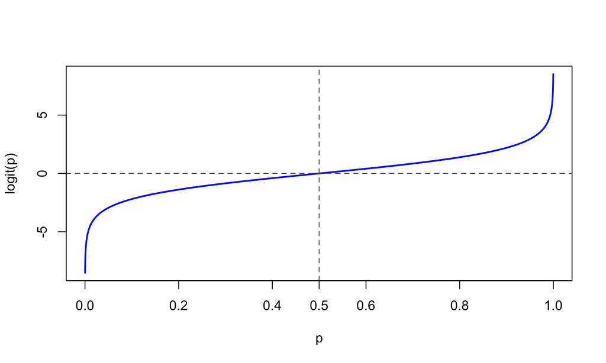

## expit

\[expit(x) = \dfrac{e^x}{1+e^x}\ \in\ [0,1]\]

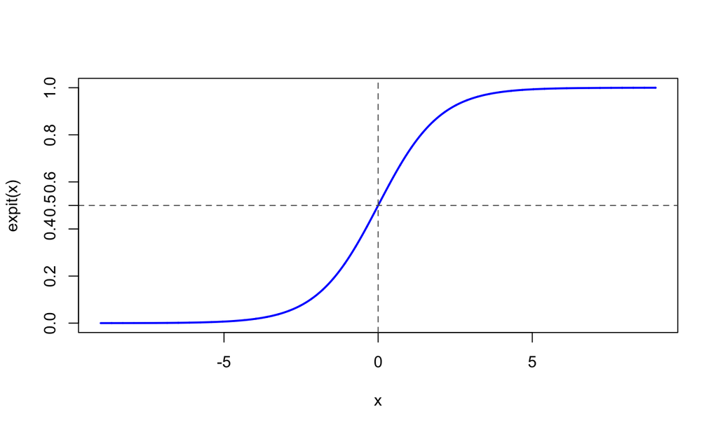

**NB**: \(expit(logit(p))=p\) et \(logit(expit(x))=x\)

## logistic regression

\[logit\left(\mathbb{P}(Y=1|x_1,x_2,\dots,x_p)\right) = \beta_0+\beta_1x_1 + \beta_2 x_2 +\dots + \beta_p x_p\]

\(\Rightarrow \mathbb{P}(Y=1|x_1,x_2,\dots,x_p) = \dfrac{e^{\beta_0+\beta_1x_1 + \beta_2 x_2 +\dots + \beta_p x_p}}{1 + e^{\beta_0+\beta_1x_1 + \beta_2 x_2 +\dots + \beta_p x_p}}\)

- the \(logit\) is called the **link function**:  
  makes the link between the expectation of the outcome and the linear model

**NB**: No error term, randomness is directly encompassed into the model

## Odds and Odds Ratio

- \(\dfrac{p}{1-p}\)

If \(logit(\mathbb{P}(Y=1|x) = \beta_0 + \beta_1x\): \[log(\frac{\mathbb{P}(Y=1|X=a)}{1-\mathbb{P}(Y=1|X=a)}) - log\left(\frac{\mathbb{P}(Y=1|X=a)}{1 -\mathbb{P}(Y=1|X=a+1)}\right) = \beta_1\] Odds Ratio (OR): \(OR_{X}=e^{\beta_1}\)

## CI and OR

\(CI(OR)_{1-\alpha} = [e^{\hat{\beta_1} ± u_{1-\alpha}\hat{s}(\beta_1)}]\)

❗️Normal asymptotic approximation \(\Rightarrow\) **Wald test**:

\[\dfrac{\hat{\beta_1}}{\hat{s}(\beta_1)}\underset{H_0}{\sim}\mathcal{N}(0,1)\quad\text{when}\quad n\rightarrow\infty\]

## linearity hypothesis

One way to assess the linearity hypothesis is to split-up the continuous covariates into categories and check that the coefficients associated with each categories are coherent with a linear relationship.

**This is the only hypothesis to be check in the *logistic regression***

## Practicals 4

+

- 👉 load the data from `birthweight_data.txt`
- 👉 how can you best explain the binary variable `low` from the other variables ? Use the `glm()` function with the `"binomial link"`
- 👉 change the reference category for race to obtain the CI for the OR for smoking in black women

## Generalized Linear Models (GLM)

- Poisson regression for discrete quantitative outcome (e.g. counts)  
  *link function is the \(log\)*
- Probit & Tobit models as alternatives to logistic regression  
  (different *link functions*)
- …

## Independence

GLM assume that all the observations are \(iid\)

Linear mixed-effect models can be used to model grouped data

Ex: longitudinal data, batch effects, etc…

## Conclusion

## Regression analysis steps

Regardless of which regression model you are using:

1. **Model specification** according to the research question, and the data available
2. **Estimation** with point estimates and **Confidence Intervals** for the model parameters
3. Significance testing for each model parameters of interest
4. Model fit diagnoses
5. Results presentation (often as a table)
6. Results interpretation and discussion

## Additional resources

Points of significance | Statistics for Biologists series:

- [Altman & Krzywinski (2015) Simple linear regression *Nature Methods* **12**:999–1000](https://www.nature.com/articles/nmeth.3627)
- [Altman & Krzywinski (2015) Multiple linear regression *Nature Methods* **12**:1103–1104](https://www.nature.com/articles/nmeth.3665)
- [Lever, Altman & Krzywinski (2015), Logistic regression *Nature Methods* **13**:541–542](https://www.nature.com/articles/nmeth.3904)
- [Altman & Krzywinski (2016) Analyzing outliers: influential or nuisance ? *Nature Methods* **13**:281–282](https://www.nature.com/articles/nmeth.3812)
- [Altman & Krzywinski (2016) Regression diagnosis *Nature Methods* **13**:385–386](https://www.nature.com/articles/nmeth.3854)